# Exploraity Data Analysis

# Explore and Summarize Loan Data from Prosper – by Reem Bin Hezam

```
## [1] "C:/Users/Administrator/Dropbox/Udacity/P4/quizes/P4 Rmd Files"
```

# Introduction

Prosper is a marketplace providing person-to-person lending utilizing a listing and bidding process to get competitive rates for loans.

This analysis will explore a dataset about loan data from prosper (last updated 03/11/2014).

**The dataset (link):** This data set contains 113,937 loans with 81 variables on each loan, including loan amount, borrower rate (or interest rate), current loan status, borrower income, borrower employment status, borrower credit history, and the latest payment information.

**The dataset dictionary (link):** This variable dictionary explains the variables in the data set.

On the next section, I will start exploring and ask questions about the data set. The goal is to explore between 10-15 variables in the analysis, and try to find insights and correllations between them.

# Univariate Plots Section

**Summary of data:**

```
##                ListingKey ListingNumber           ListingCreationDate
## 1 1021339766868145413AB3B        193129 2007-08-26 19:09:29.263000000
## 2 10273602499503308B223C1       1209647 2014-02-27 08:28:07.900000000
## 3 0EE9337825851032864889A         81716 2007-01-05 15:00:47.090000000
## 4 0EF5356002482715299901A        658116 2012-10-22 11:02:35.010000000
## 5 0F023589499656230C5E3E2        909464 2013-09-14 18:38:39.097000000
## 6 0F05359734824199381F61D       1074836 2013-12-14 08:26:37.093000000
##   CreditGrade Term LoanStatus          ClosedDate BorrowerAPR BorrowerRate
## 1           C   36  Completed 2009-08-14 00:00:00     0.16516       0.1580
## 2               36    Current                         0.12016       0.0920
## 3          HR   36  Completed 2009-12-17 00:00:00     0.28269       0.2750
## 4               36    Current                         0.12528       0.0974
## 5               36    Current                         0.24614       0.2085
## 6               60    Current                         0.15425       0.1314
##   LenderYield EstimatedEffectiveYield EstimatedLoss EstimatedReturn
```

[output cut: 174 more lines]

```
##                    ListingKey     ListingNumber
##  17A93590655669644DB4C06:     6   Min.   :      4
##  349D3587495831350F0F648:     4   1st Qu.: 400919
##  47C1359638497431975670B:     4   Median : 600554
##  8474358854651984137201C:     4   Mean   : 627886
##  DE8535960513435199406CE:     4   3rd Qu.: 892634
##  04C13599434217079754AEE:     3   Max.   :1255725
##  (Other)                :113912
##                     ListingCreationDate  CreditGrade         Term
##  2013-10-02 17:20:16.550000000:     6          :84984   Min.   :12.00
##  2013-08-28 20:31:41.107000000:     4   C      : 5649   1st Qu.:36.00
##  2013-09-08 09:27:44.853000000:     4   D      : 5153   Median :36.00
##  2013-12-06 05:43:13.830000000:     4   B      : 4389   Mean   :40.83
##  2013-12-06 11:44:58.283000000:     4   AA     : 3509   3rd Qu.:36.00
##  2013-08-21 07:25:22.360000000:     3   HR     : 3508   Max.   :60.00
##  (Other)                      :113912   (Other): 6745
##                  LoanStatus                  ClosedDate
##  Current              :56576                      :58848
##  Completed            :38074   2014-03-04 00:00:00:  105
##  Chargedoff           :11992   2014-02-19 00:00:00:  100
##  Defaulted            : 5018   2014-02-11 00:00:00:   92
##  Past Due (1-15 days) :  806   2012-10-30 00:00:00:   81
##  Past Due (31-60 days):  363   2013-02-26 00:00:00:   78
##  (Other)              : 1108   (Other)            :54633
##   BorrowerAPR       BorrowerRate     LenderYield
##  Min.   :0.00653   Min.   :0.0000   Min.   :-0.0100
##  1st Qu.:0.15629   1st Qu.:0.1340   1st Qu.: 0.1242
##  Median :0.20976   Median :0.1840   Median : 0.1730
##  Mean   :0.21883   Mean   :0.1928   Mean   : 0.1827
##  3rd Qu.:0.28381   3rd Qu.:0.2500   3rd Qu.: 0.2400
##  Max.   :0.51229   Max.   :0.4975   Max.   : 0.4925
##  NA's   :25
##  EstimatedEffectiveYield EstimatedLoss   EstimatedReturn
##  Min.   :-0.183          Min.   :0.005   Min.   :-0.183
##  1st Qu.: 0.116          1st Qu.:0.042   1st Qu.: 0.074
##  Median : 0.162          Median :0.072   Median : 0.092
##  Mean   : 0.169          Mean   :0.080   Mean   : 0.096
##  3rd Qu.: 0.224          3rd Qu.:0.112   3rd Qu.: 0.117
##  Max.   : 0.320          Max.   :0.366   Max.   : 0.284
##  NA's   :29084           NA's   :29084   NA's   :29084
```

[output cut: 193 more lines]

```
##  Min.   :    0.00                Min.   :0.7000   Min.   : 0.00000
##  1st Qu.:    0.00                1st Qu.:1.0000   1st Qu.: 0.00000
##  Median :    0.00                Median :1.0000   Median : 0.00000
##  Mean   :   25.14                Mean   :0.9986   Mean   : 0.04803
##  3rd Qu.:    0.00                3rd Qu.:1.0000   3rd Qu.: 0.00000
##  Max.   :21117.90                Max.   :1.0125   Max.   :39.00000
##
##  InvestmentFromFriendsCount InvestmentFromFriendsAmount   Investors
##  Min.   : 0.00000           Min.   :    0.00            Min.   :   1.00
##  1st Qu.: 0.00000           1st Qu.:    0.00            1st Qu.:   2.00
##  Median : 0.00000           Median :    0.00            Median :  44.00
##  Mean   : 0.02346           Mean   :   16.55            Mean   :  80.48
##  3rd Qu.: 0.00000           3rd Qu.:    0.00            3rd Qu.: 115.00
##  Max.   :33.00000           Max.   :25000.00            Max.   :1189.00
##
```

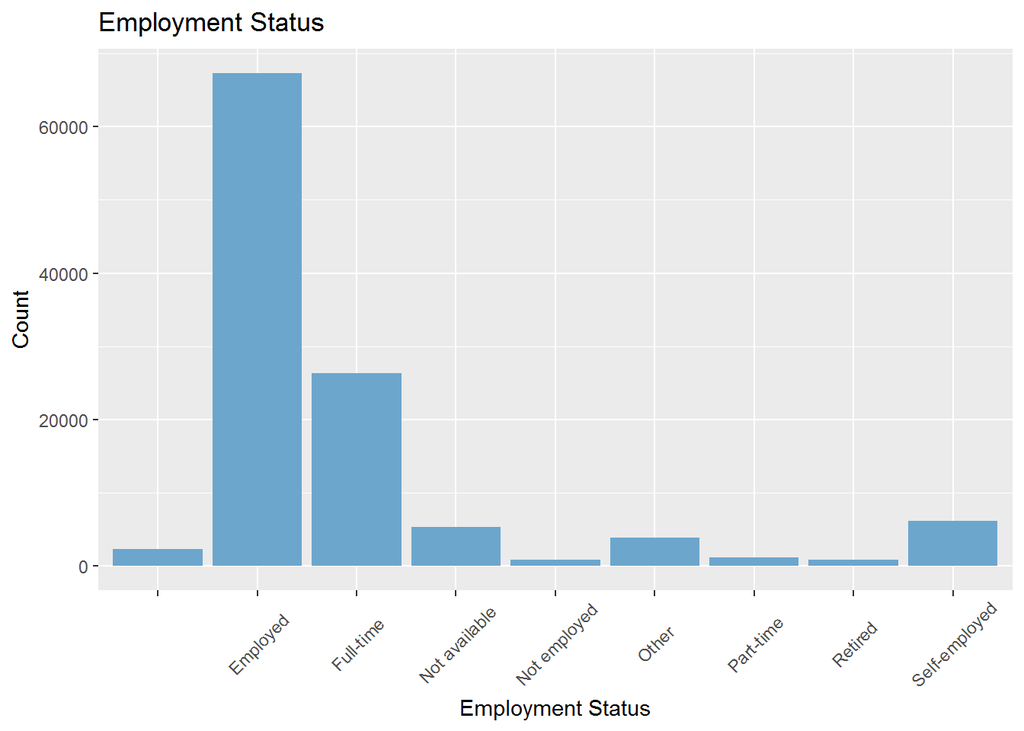

Most of the borrowers have jobs.

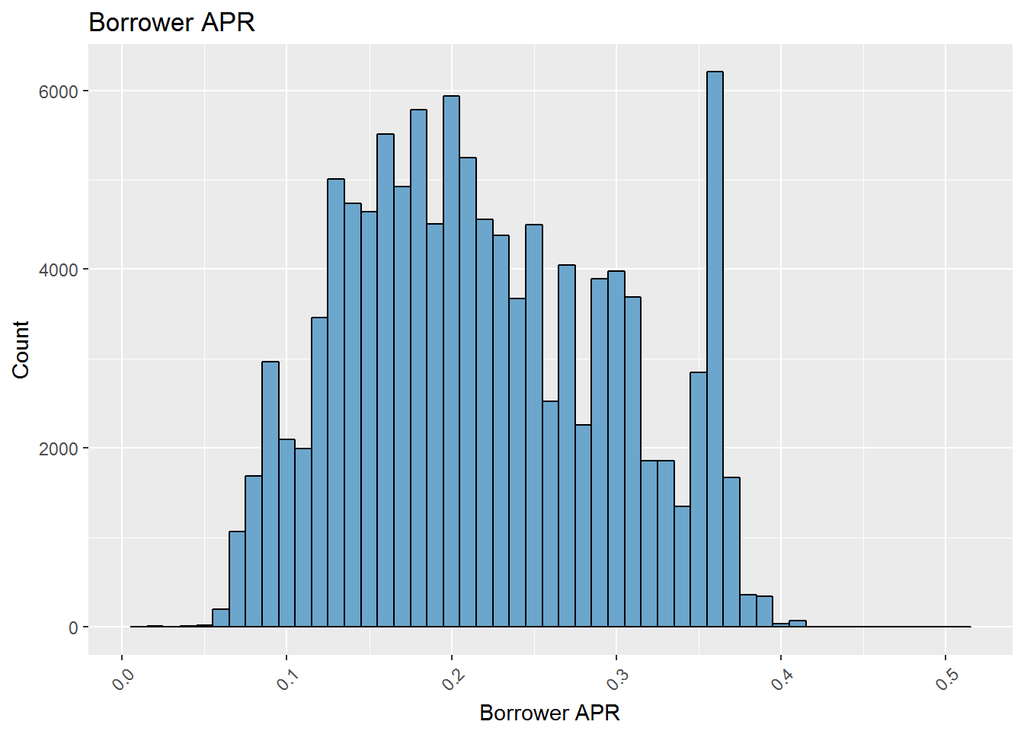

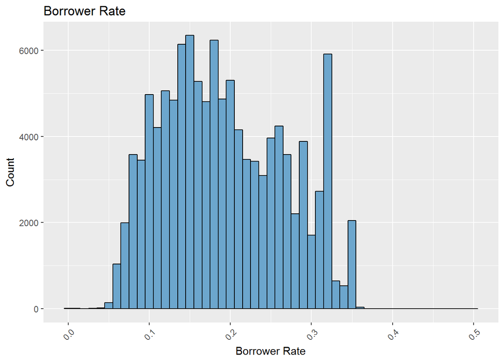

No big difference beteween Rate and APR

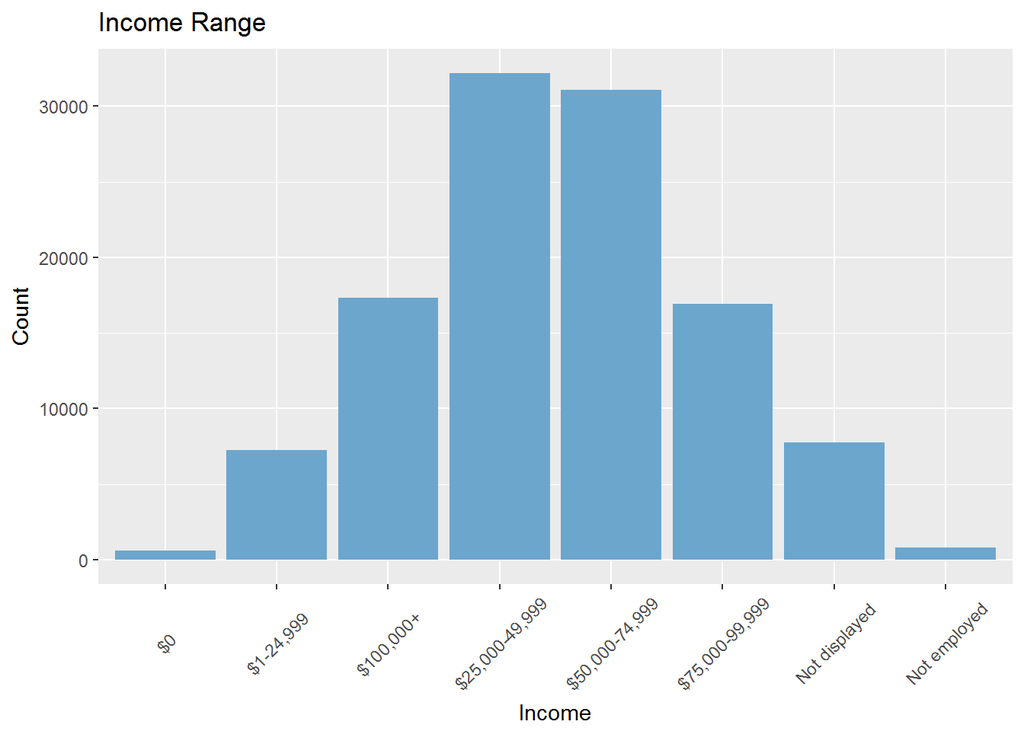

People with very low income have very few number of loans in general.

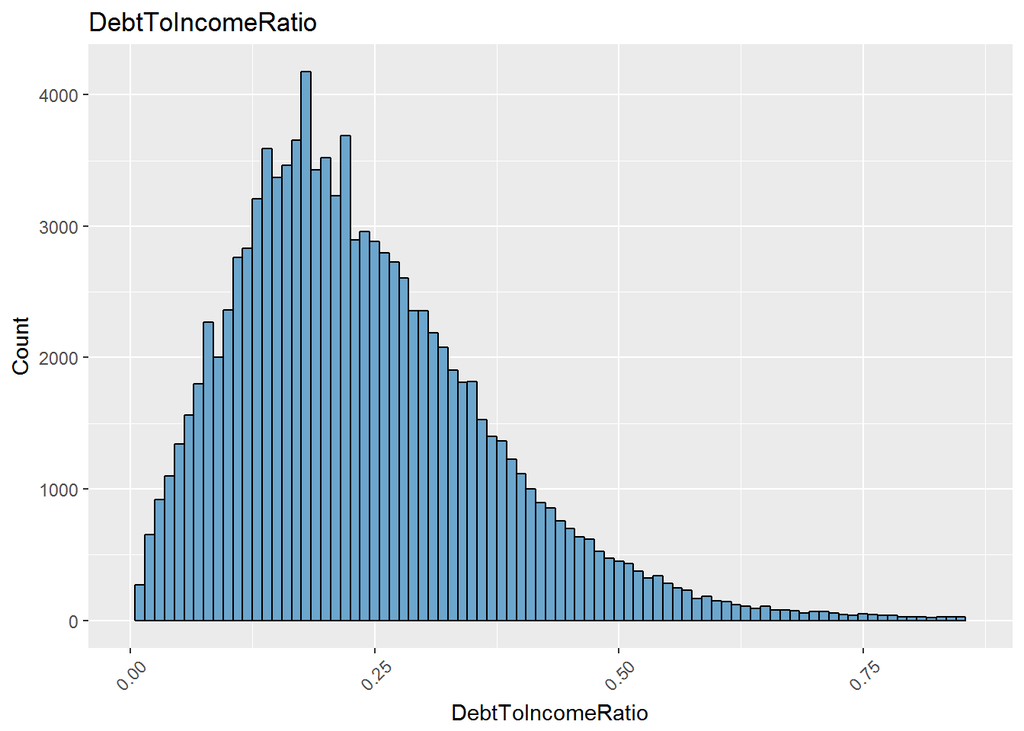

People with high debt to income ration have very few number of loans.

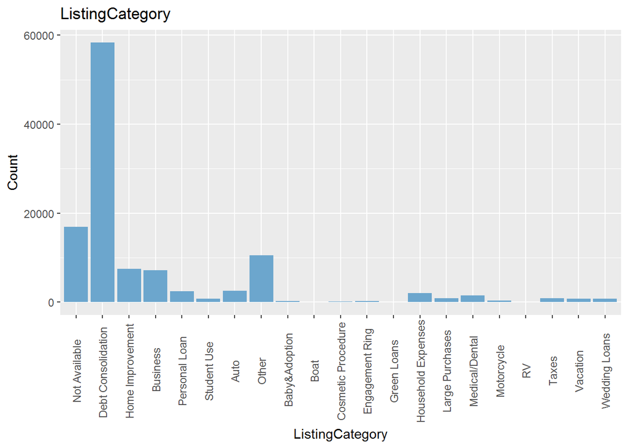

```
##       Not Available Debt Consolidation     Home Improvement
##               16965               58308                7433
##            Business       Personal Loan         Student Use
##                7189                2395                 756
##                Auto               Other       Baby&Adoption
##                2572               10494                 199
##                Boat  Cosmetic Procedure     Engagement Ring
##                  85                  91                 217
##         Green Loans  Household Expenses     Large Purchases
##                  59                1996                 876
##      Medical/Dental          Motorcycle                  RV
##                1522                 304                  52
##               Taxes            Vacation       Wedding Loans
##                 885                 768                 771
```

Most loans were taken for debt consolidation.

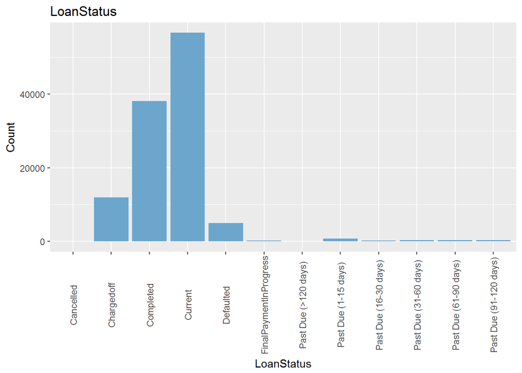

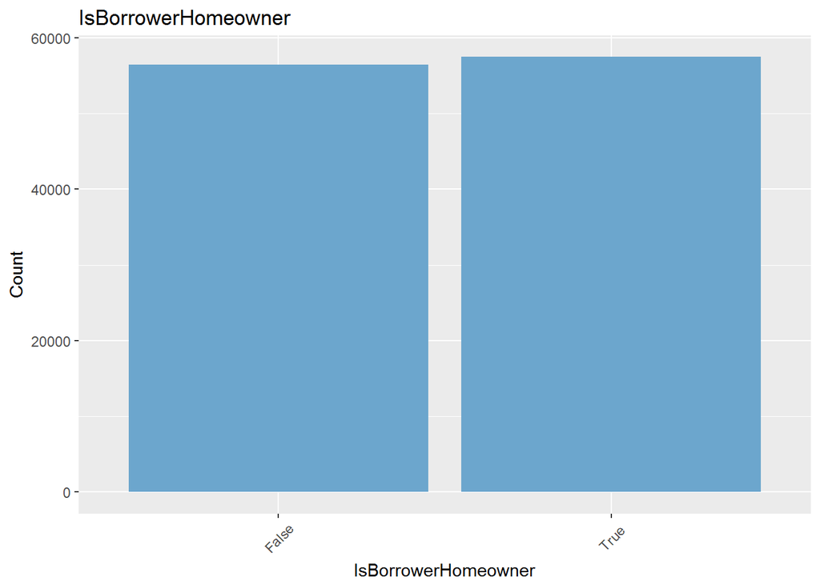

Seems there is no difference on borrowing chance wether to be a home owner or not

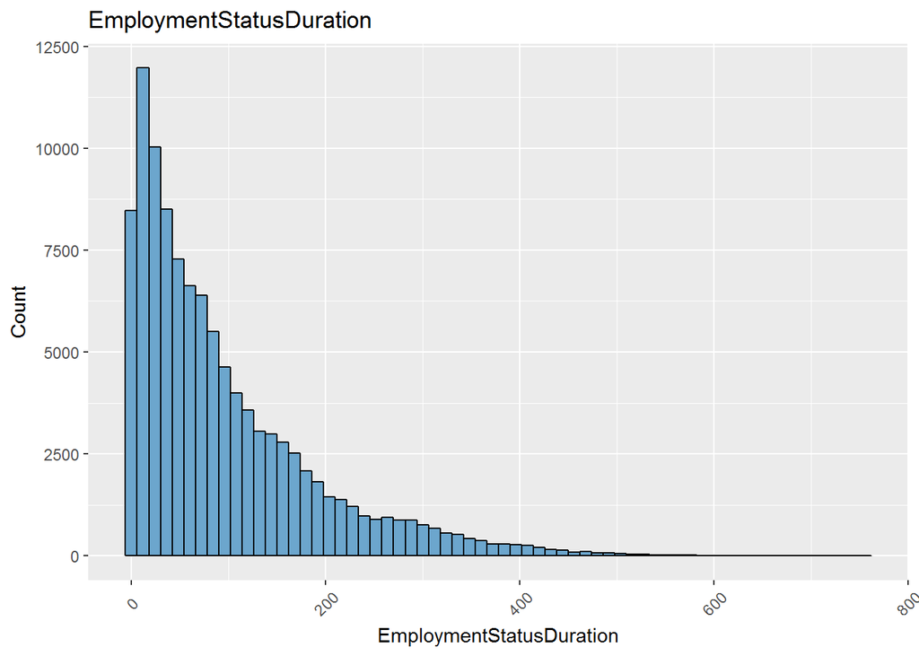

```
##    Min. 1st Qu.  Median    Mean 3rd Qu.    Max.    NA's
##    0.00   26.00   67.00   96.07  137.00  755.00    7625
```

New employed are the most borrowers

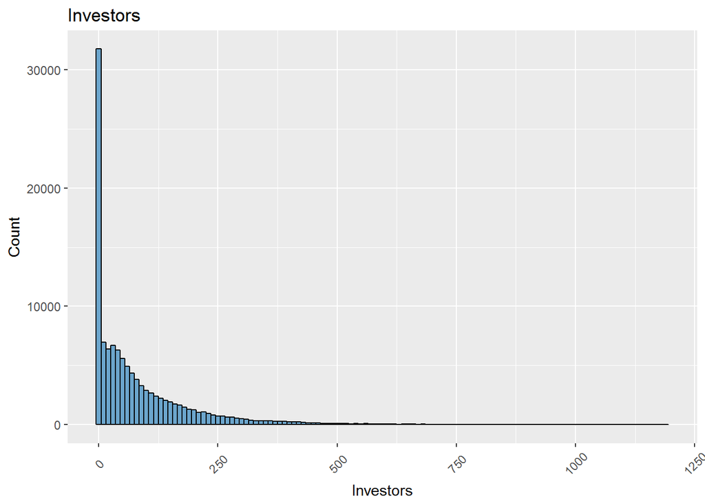

```
##    Min. 1st Qu.  Median    Mean 3rd Qu.    Max.
##    1.00    2.00   44.00   80.48  115.00 1189.00
```

# Univariate Analysis

### What is the structure of your dataset?

As mentioned above, This data set contains 113,937 loans with 81 variables on each loan, including loan amount, borrower rate (or interest rate), current loan status, borrower income, borrower employment status, borrower credit history, and the latest payment information.

### What is/are the main feature(s) of interest in your dataset?

The main feature of intrest is the loan status and the employment status and the income.

### What other features in the dataset do you think will help support your investigation into your feature(s) of interest?

Other features like reason for loan and amount of loan would help in the investigation.

### Did you create any new variables from existing variables in the dataset?

Yes the alpha for the listingCategory factors since it was available on number only so I added their description.

### Of the features you investigated, were there any unusual distributions? Did you perform any operations on the data to tidy, adjust, or change the form of the data? If so, why did you do this?

No

# Bivariate Plots Section

In this section i will explore relationships between some pair of variables from the above analysis.

```r
#pairs.panels(select(EmploymentStatus, LoanStatus, ListingCategory..Alpha, BorrowerAPR),
#                            hist.col = 'skyblue3', col = 'skyblue3')


#  above code causes this error dont know why
#Error in select(EmploymentStatus, LoanStatus, ListingCategory..Alpha, : unused arguments (LoanStatus, ListingCategory..Alpha, BorrowerAPR)
```

I wanted to make a Correlation_Overview matrix but the pairs.panels didnt work !!

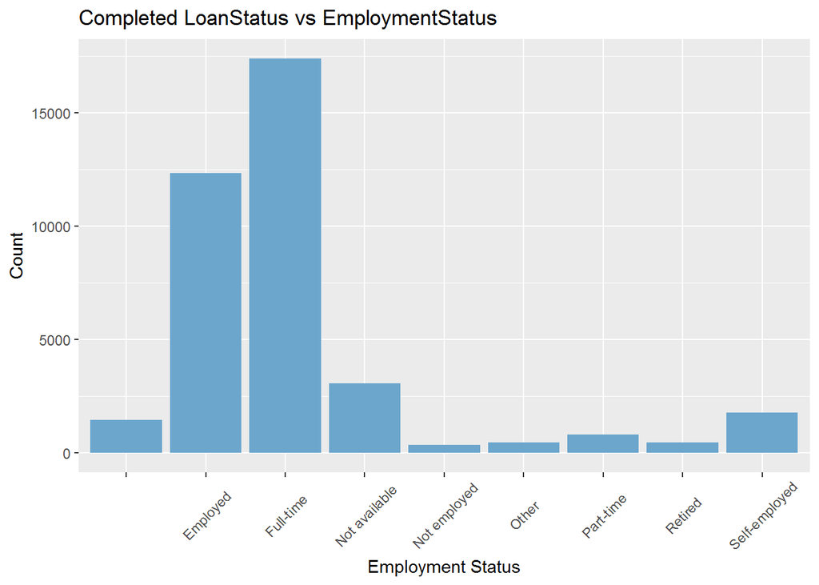

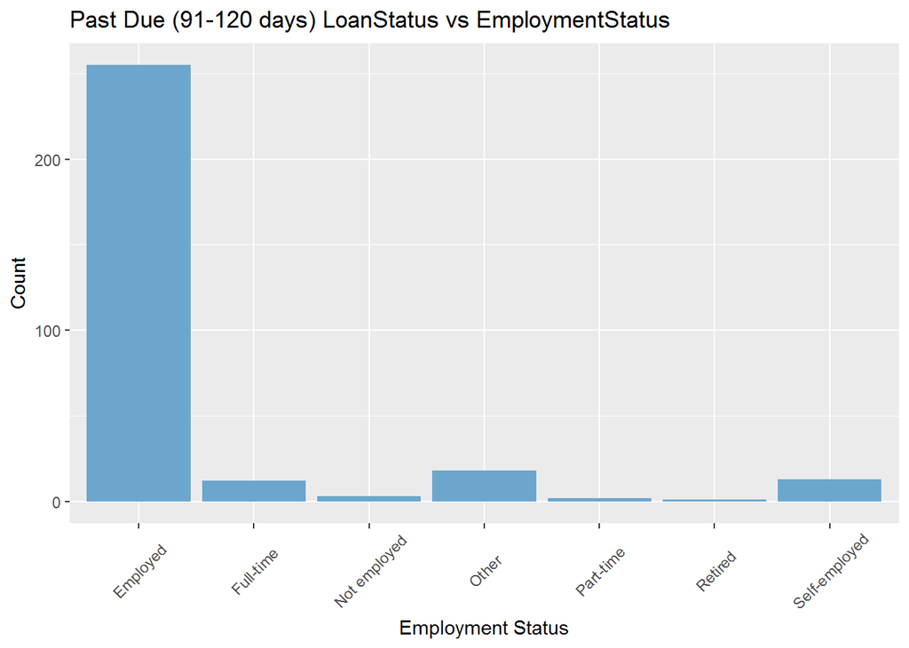

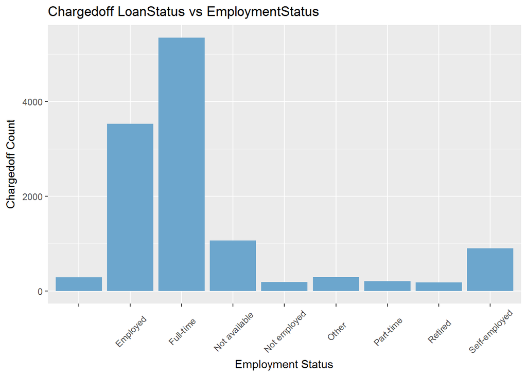

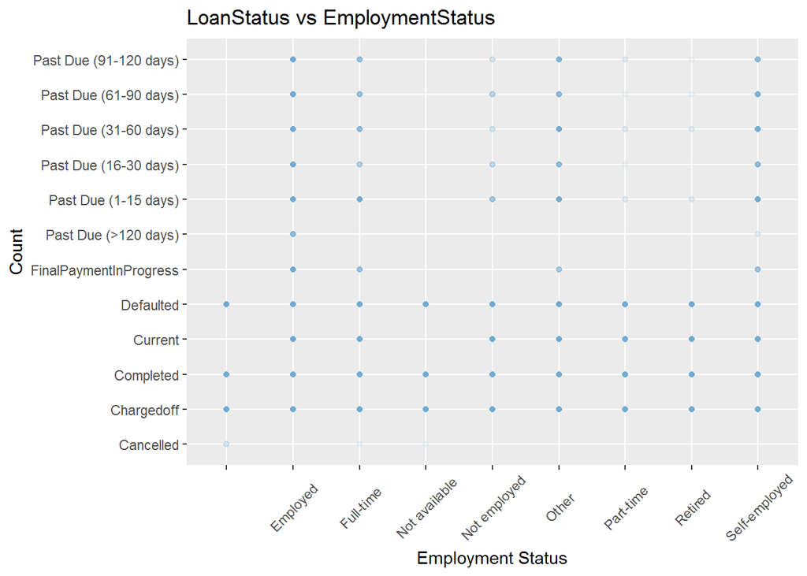

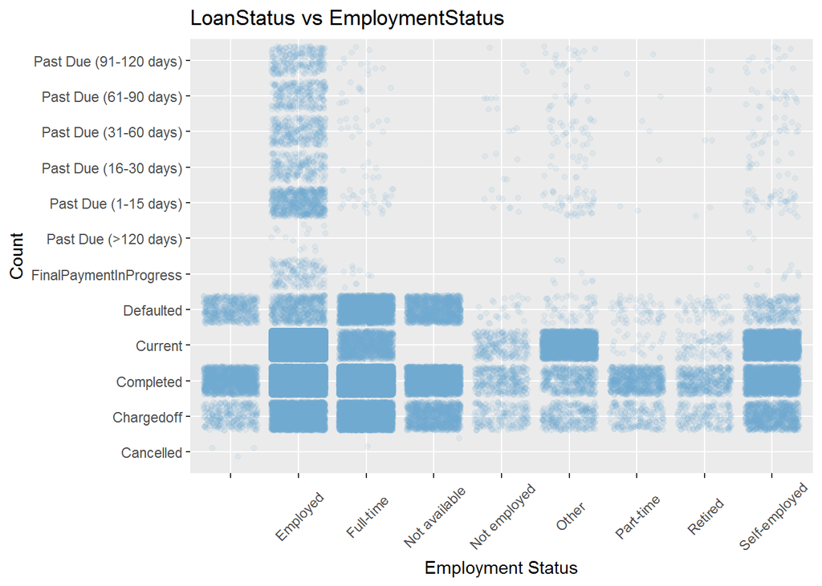

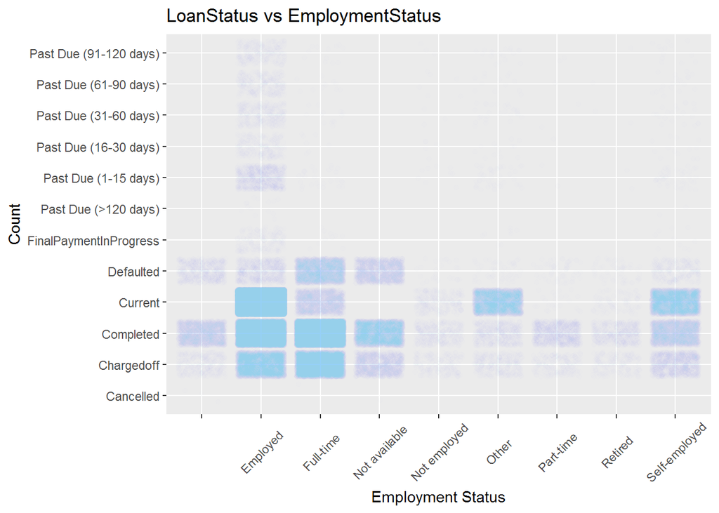

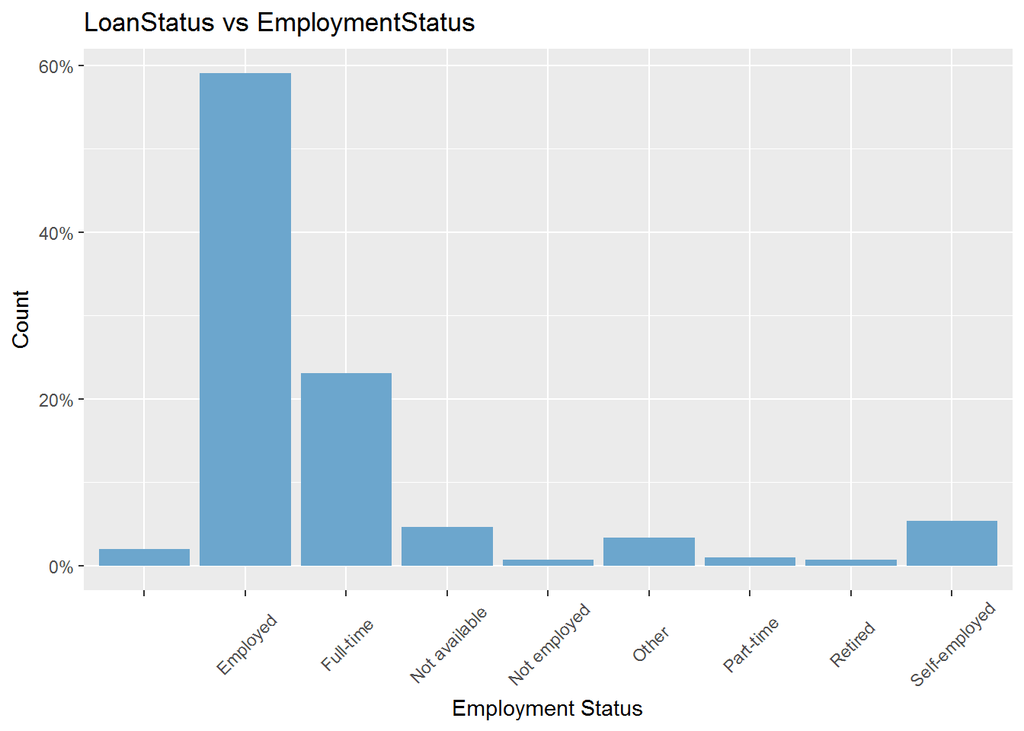

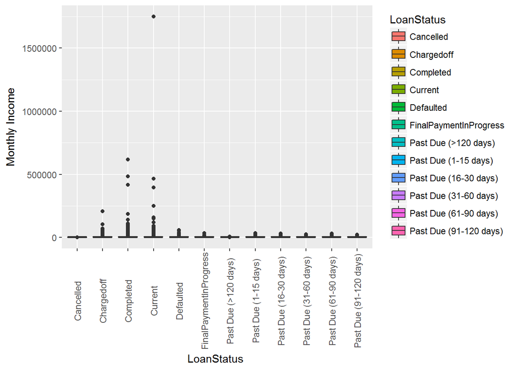

```
## $title
## [1] "Monthly Income vs LoanStatus"
##
## $subtitle
## NULL
##
## attr(,"class")
## [1] "labels"
```

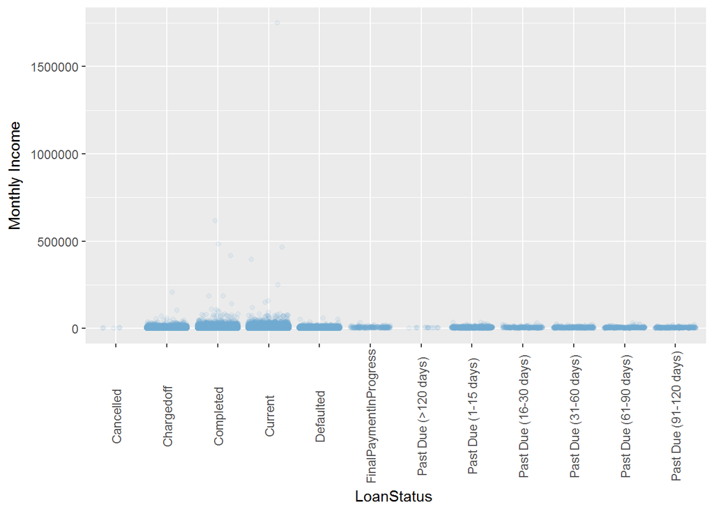

```
## $title
## [1] "Monthly Income vs LoanStatus"
##
## $subtitle
## NULL
##
## attr(,"class")
## [1] "labels"
```

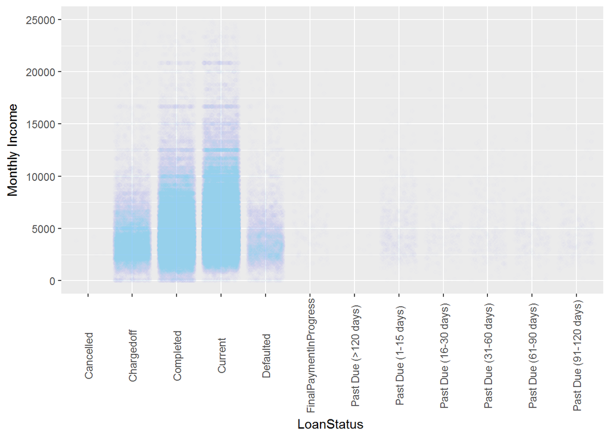

```
## $title
## [1] "Monthly Income vs LoanStatus"
##
## $subtitle
## NULL
##
## attr(,"class")
## [1] "labels"
```

Could not find big relation between loan status and income !

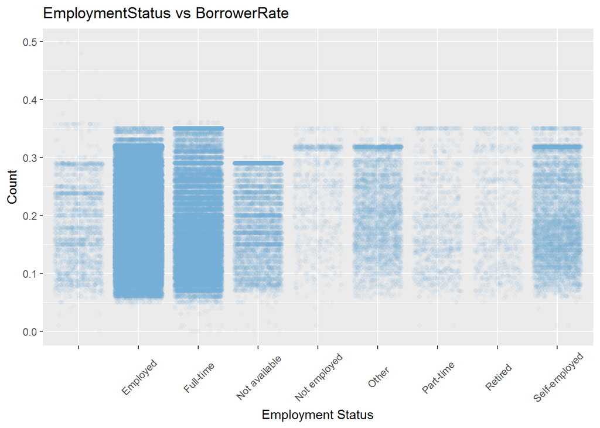

# Bivariate Analysis

### Did you observe any interesting relationships between the other features (not the main feature(s) of interest)?

No

### What was the strongest relationship you found?

There is no strong relationship !!!

# Multivariate Plots Section

In this section i will explore relationships between a number of variables from the dataset.

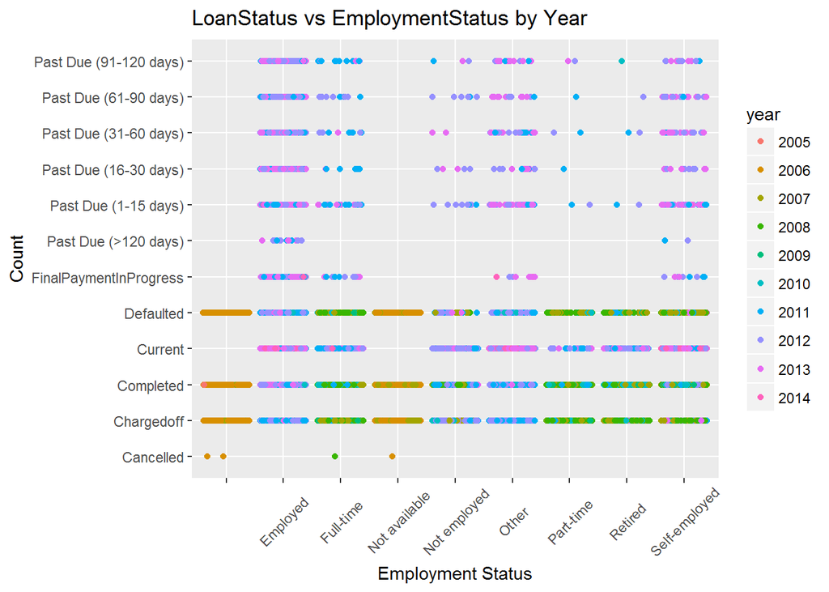

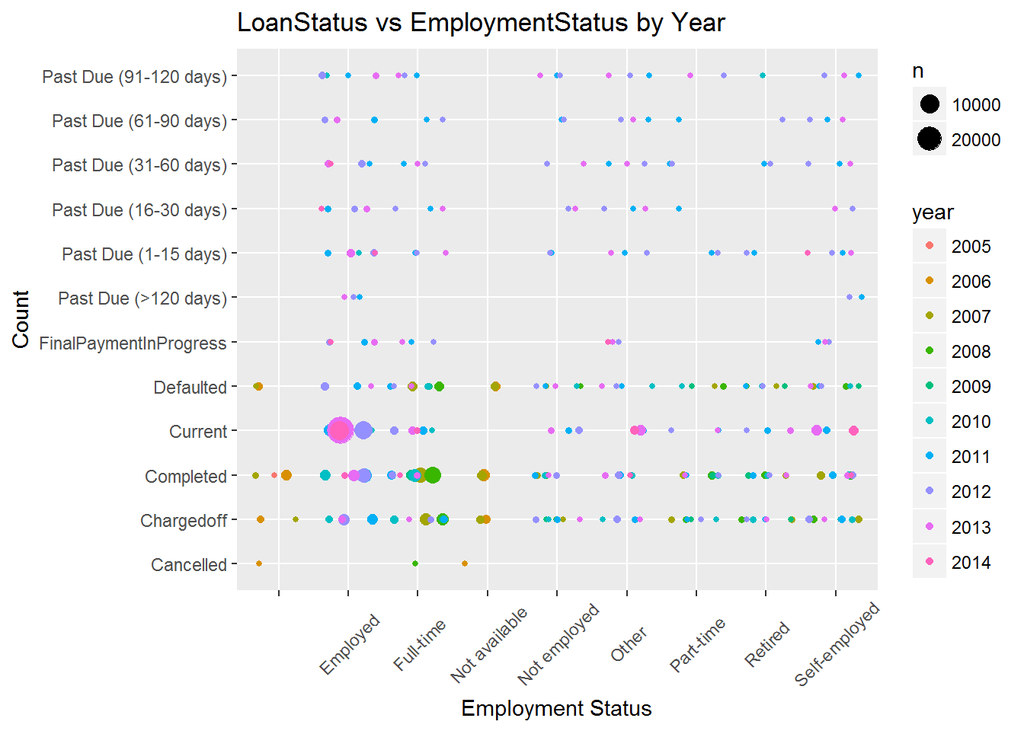

Most of current loans are in 2013 and 2014 for employed borrowers.

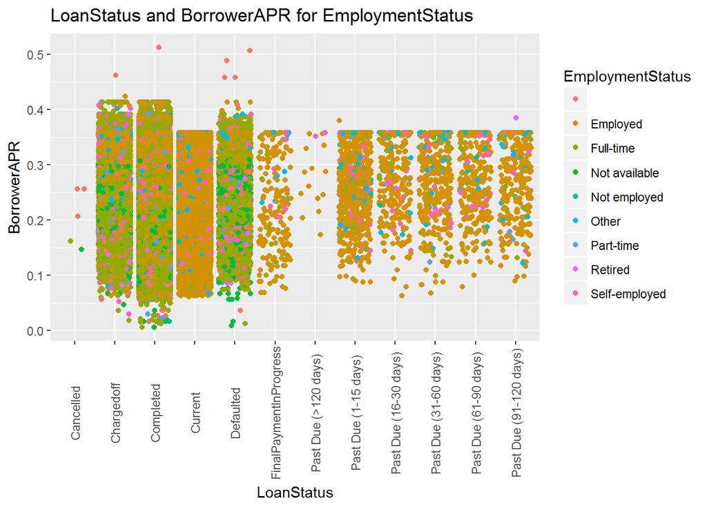

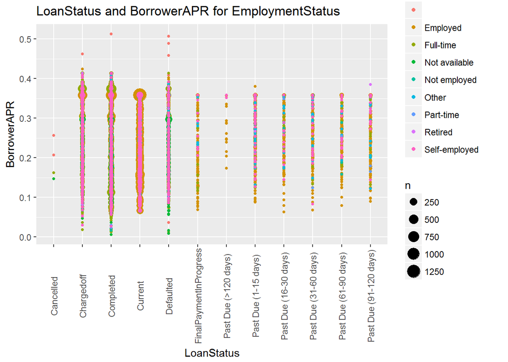

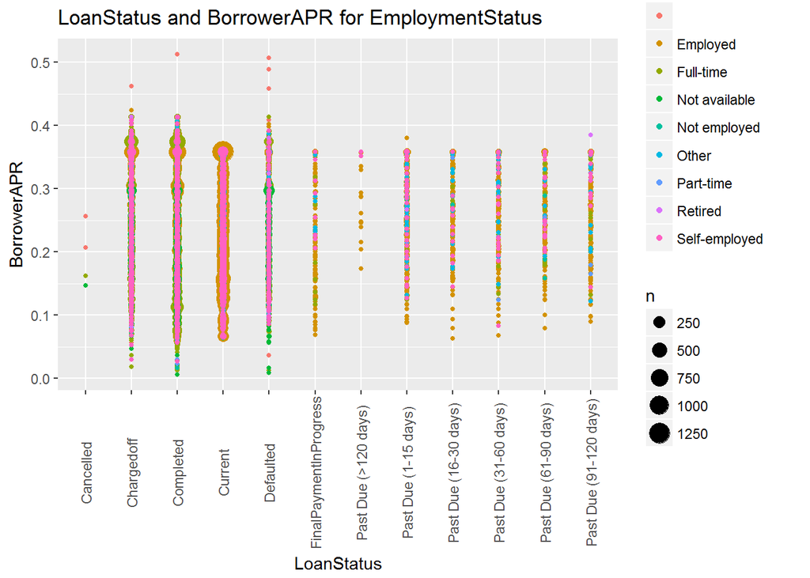

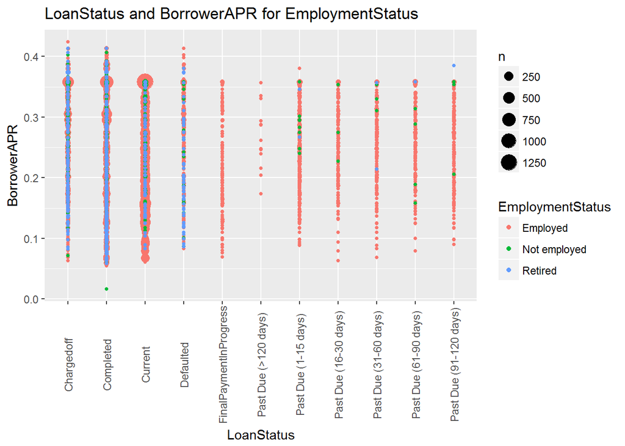

Most charged off loans have high APR. On hte other hand also most completed loans have high APR !! Very few retired have past due loan status

# Multivariate Analysis

### Talk about some of the relationships you observed in this part of the investigation. Were there features that strengthened each other in terms of looking at your feature(s) of interest?

Most of current loans are in 2013 and 2014 for employed borrowers.

### Were there any interesting or surprising interactions between features?

Not sure ! factore are too much to be able to find relationships among them !!

### OPTIONAL: Did you create any models with your dataset? Discuss the strengths and limitations of your model.

# Final Plots and Summary

### Plot One

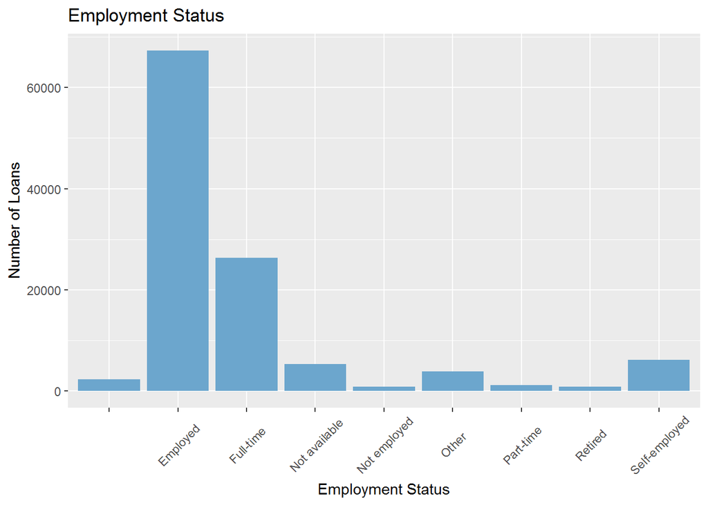

### Description One

Most of the borrowers have jobs. More than half of the dataset are employed. about 25000 have a full time job. Which means that being employed is an important factore to get a loan.

### Plot Two

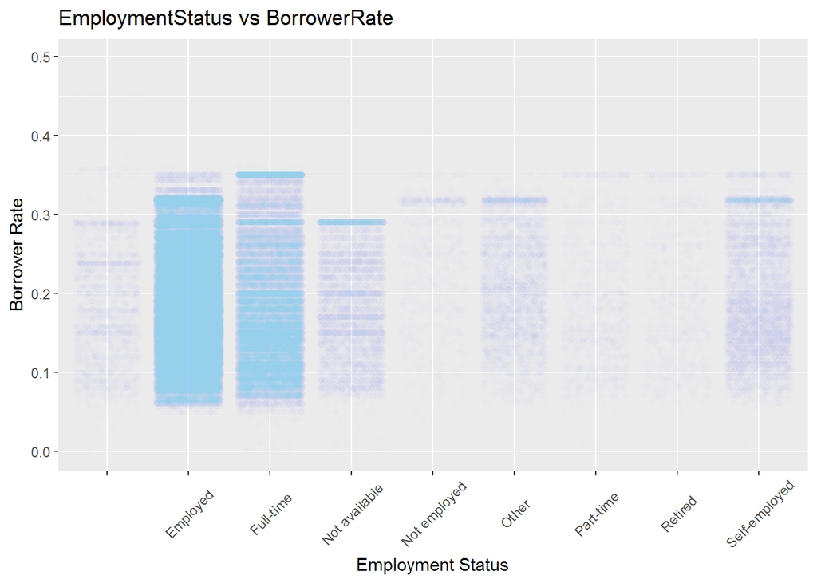

### Plot Three

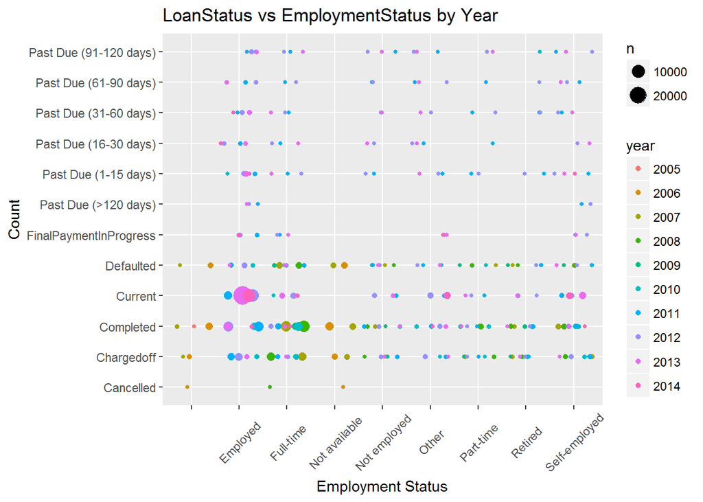

### Description Three

Year 2013 then 2014 have the most number of current loans.

# Reflection

Data needs to be categorized in a better way! what is the different between emplyed and full-time vs part time ?

Too many factors and variables makes it difficult to explore related ones.

The most useful insights come from the simple one variable analysis.